# Analyse PCAWG samples

# PCAWG results

Analyse results from running SVclone on PCAWG samples.

## Supplementary Figure 5

Number of SVs versus purity for all PCWAG samples on which SVclone was run with >0 SVs.

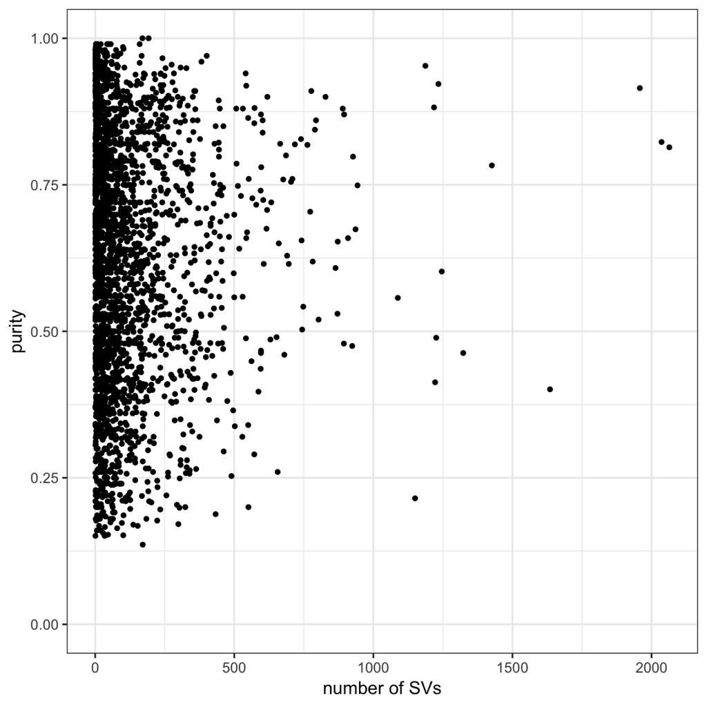

$R^2$ of purity versus number of SVs.

```
## [1] 0.0006608068
```

Check fraction of samples called with single clonal cluster.

```
## [1] "Proportion called using SV data:"
```

```
## [1] 0.0008196721
```

```
## [1] "Proportion called using SNV data:"
```

```
## [1] 0.002936858
```

## Figure 6a

PCAWG SV versus SNV subclonal fractions. Lines repesent density.

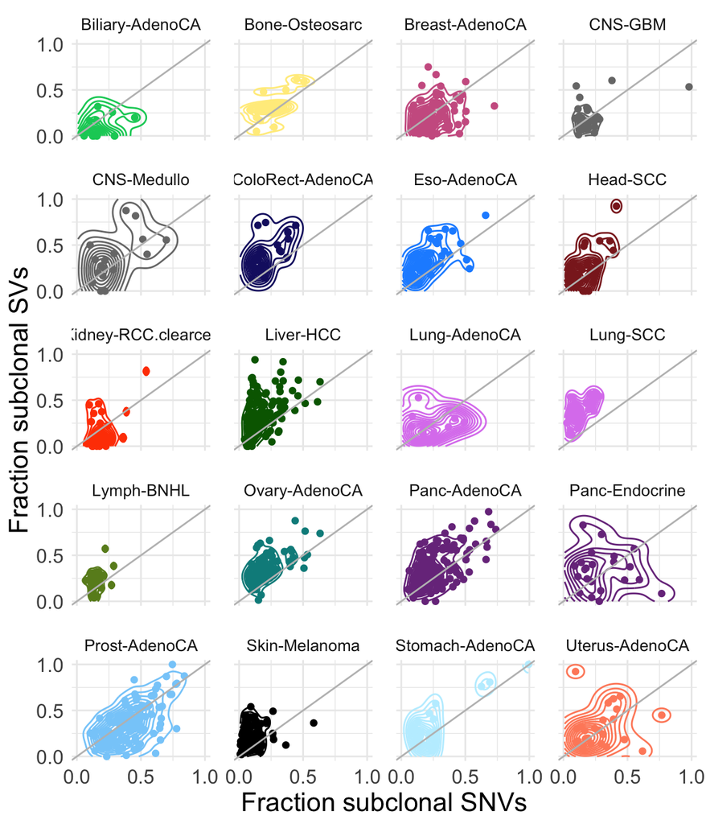

## Supplementary Table 4

PCAWG SV versus SNV statistics per histological group.

```
##                histology n_samples subclonal_sv_enriched_samples
## 14              Lung-SCC        37                            37
## 1          Ovary-AdenoCA        93                            86
## 13      ColoRect-AdenoCA        26                            24
## 2              Liver-HCC       156                           133
## 17           Eso-AdenoCA        48                            41
## 12         Skin-Melanoma        75                            61
## 20        Bone-Osteosarc        18                            14
## 9           Panc-AdenoCA       179                           132
## 10            Lymph-BNHL        26                            19
## 16              Head-SCC        33                            23
## 18       Stomach-AdenoCA        23                            16
## 6         Uterus-AdenoCA        26                            17
## 15           CNS-Medullo        17                            10
## 3         Panc-Endocrine        21                            12
```

[output cut: 31 more lines]

## Supplementary Figure 6

Subset classification across cancer types, ranked by number of SCNR samples.

```
##      LIRI
## 0.1035857
```

```
##        OV
## 0.2566372
```

```
##       PACA
## 0.07531381
```

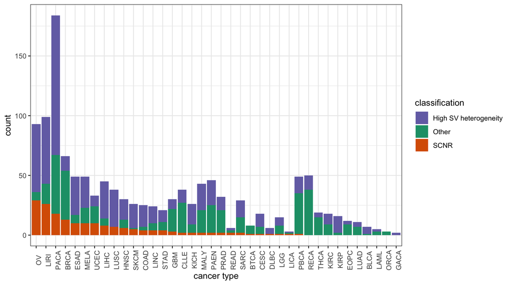

```
## Call: survfit(formula = SurvObj ~ classification, data = surv, conf.type = "log-log")
##
##    210 observations deleted due to missingness
##                                        n events median 0.95LCL 0.95UCL
## classification=High SV heterogeneity 650    279   1470    1315    1768
## classification=Other                 447    144   2907    2197    5378
## classification=SCNR                  177     83   1236     806    1699
```

## Figure 6b

Survival curve comparing SCNR, high-SV heterogeneity and all other PCAWG samples.

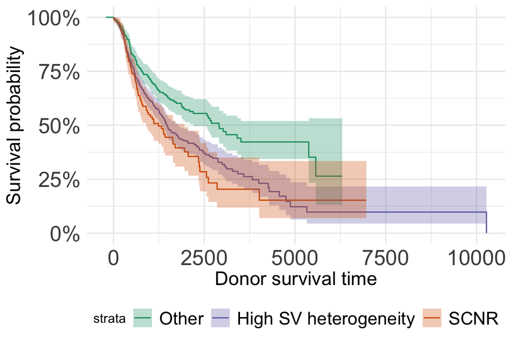

```
## Call:
## coxph(formula = Surv(donor_survival_time, status) ~ classification +
##     strata(histology_tier4, age.cat, sv.bin), data = xclin)
##
##   n= 1244, number of events= 497
##    (240 observations deleted due to missingness)
##
##                                       coef exp(coef) se(coef)     z
## classificationHigh SV heterogeneity 0.2642    1.3024   0.1530 1.728
## classificationSCNR                  0.6576    1.9301   0.2061 3.190
##                                     Pr(>|z|)
## classificationHigh SV heterogeneity  0.08406 .
## classificationSCNR                   0.00142 **
## ---
## Signif. codes:  0 '***' 0.001 '**' 0.01 '*' 0.05 '.' 0.1 ' ' 1
##
##                                     exp(coef) exp(-coef) lower .95
## classificationHigh SV heterogeneity     1.302     0.7678    0.9651
## classificationSCNR                      1.930     0.5181    1.2887
##                                     upper .95
## classificationHigh SV heterogeneity     1.758
## classificationSCNR                      2.891
##
## Concordance= 0.537  (se = 0.02 )
## Rsquare= 0.008   (max possible= 0.612 )
## Likelihood ratio test= 10.13  on 2 df,   p=0.006
## Wald test            = 10.18  on 2 df,   p=0.006
## Score (logrank) test = 10.32  on 2 df,   p=0.006
```

Check whether there is any bias of enrichment of SCNR samples by project code.

```
##    project             hist enr_total hist_total enr_in_project proj_total
## 1    OV-AU    Ovary-AdenoCA        29         95             17         57
## 2    OV-US    Ovary-AdenoCA        29         95             12         38
## 3  LINC-JP        Liver-HCC        38        169              4         24
## 4  LIRI-JP        Liver-HCC        38        169             25         97
## 5  LIHC-US        Liver-HCC        38        169              8         45
## 6  LICA-FR        Liver-HCC        38        169              1          3
## 7  PAEN-AU   Panc-Endocrine         2         71              0         43
## 8  PAEN-IT   Panc-Endocrine         2         71              2         28
## 9  RECA-EU       Kidney-RCC         0        109              0         57
## 10 KIRC-US       Kidney-RCC         0        109              0         21
## 11 KIRP-US       Kidney-RCC         0        109              0         31
## 12 COAD-US ColoRect-AdenoCA         6         41              4         33
## 13 READ-US ColoRect-AdenoCA         6         41              2          8
## 14 MALY-DE       Lymph-BNHL         3         49              2         43
```

[output cut: 49 more lines]

## Supplementary Figure 7

Fold back inversion (FBI) fraction for high-SV heterogeneity, other and SCNR genotypes.

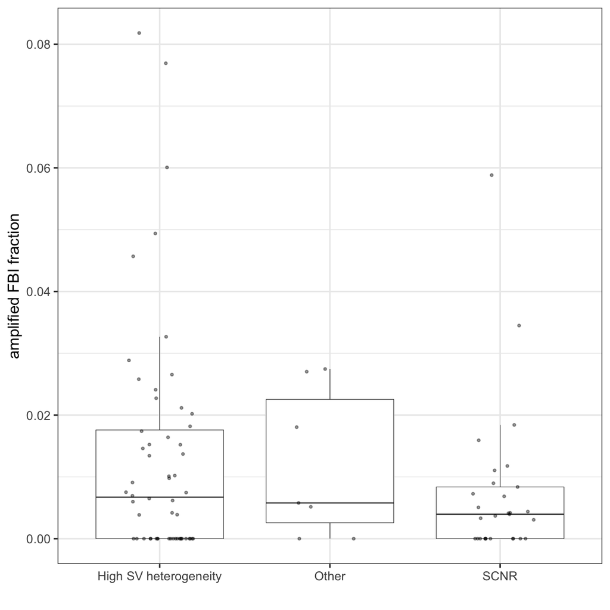

## Figure 6c-f

Plots for representative SCNR PCWAG sample bef21282.

Circos plot.

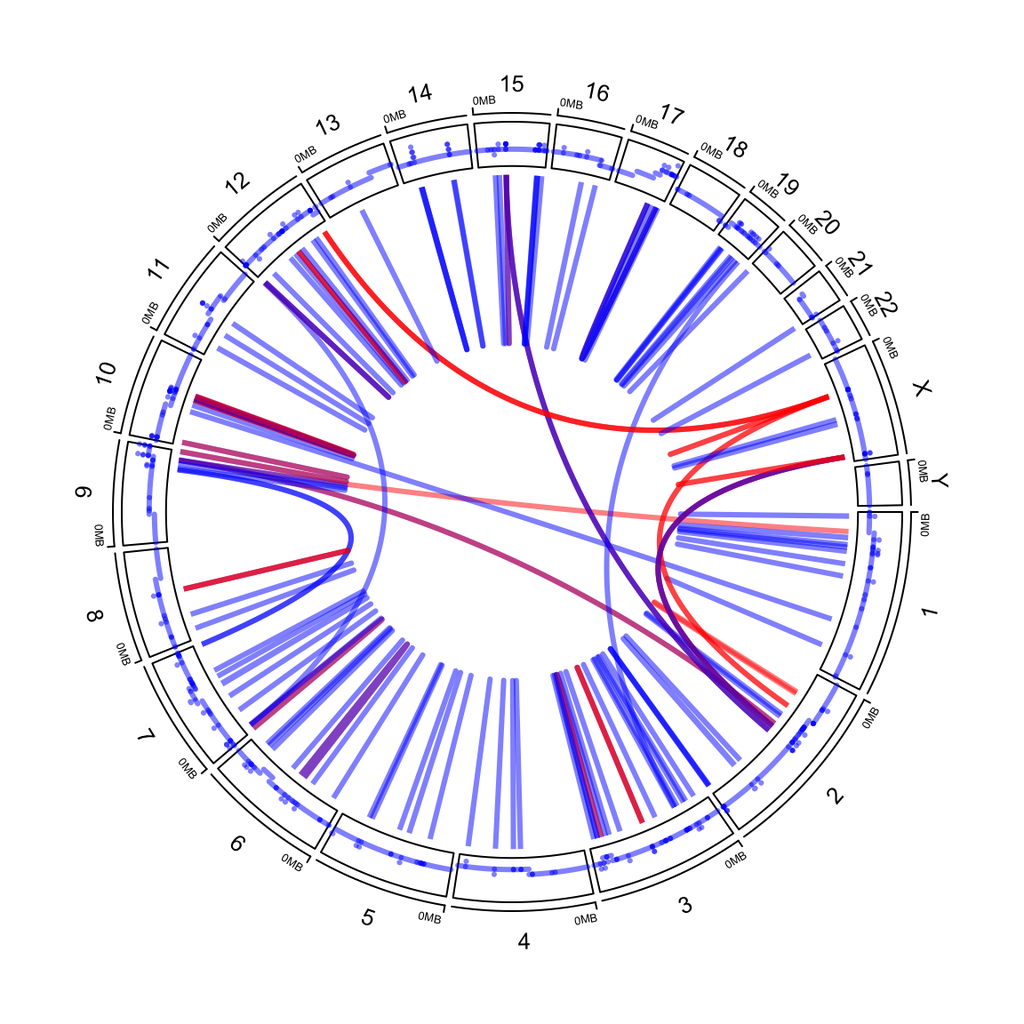

SNV CCF histogram.

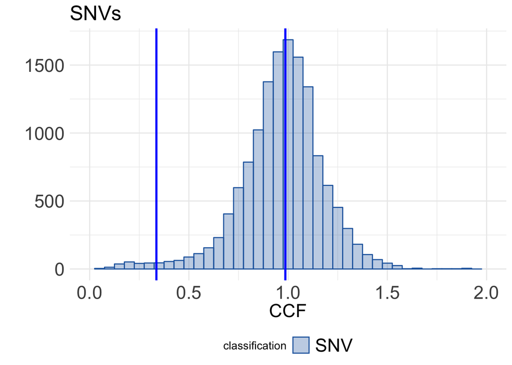

Subclonal SVs CCF histogram.

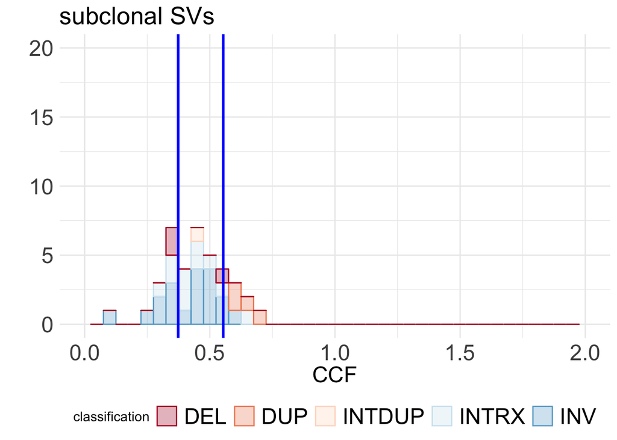

Clonal SVs CCF histogram.

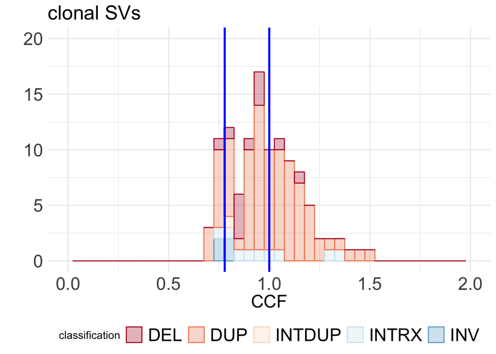

Enrichment of point mutations in driver genes per cohort versus background (other samples).

```
## [1] "SCNR samples"
```

```
##   gene         pval         qval
## 5 TP53 8.792688e-11 4.396344e-10
```

```
## [1] "HSVH samples"
```

```
##     gene         pval         qval
## 4   TP53 1.264563e-19 5.058252e-19
## 2   KRAS 6.130905e-11 1.226181e-10
## 1 CTNNB1 5.459524e-03 7.279365e-03
```

## Supplementary Table 5

Variants involved in candidate bi-allelic hits of driver genes in HSVH and SCNR cohorts. Percentages indicate fraction of cohort affected by at least one such event. Hits columns indicate the number of clonal and subclonal genes affected per cohort by the variant type.

```
##         variant cohort   clonal_num subclonal_num clonal_hits
## 1   Balanced SV   HSVH 280 (43.08%)  209 (32.15%)         554
## 2 Unbalanced SV   HSVH    377 (58%)  243 (37.38%)         963
## 3     SNV/INDEL   HSVH 511 (78.62%)  100 (15.38%)        1084
## 4           LoH   HSVH 634 (97.54%)      NA (NA%)       86535
## 5   Balanced SV   SCNR 118 (66.67%)  110 (62.15%)         318
## 6 Unbalanced SV   SCNR 156 (88.14%)    97 (54.8%)         773
## 7     SNV/INDEL   SCNR 138 (77.97%)   18 (10.17%)         275
## 8           LoH   SCNR   177 (100%)      NA (NA%)       28067
##   subclonal_hits
## 1            344
## 2            487
## 3            124
## 4             NA
## 5            238
## 6            242
## 7             20
## 8             NA
```